# Forced Turnover: Evaluating Pressing Effectiveness in Soccer

Natalie Rayce, David Almona

## Definitions

**Pressing:** a defensive tactic where players apply coordinated pressure on the opponent with the ball to force mistakes, win back possession, and quickly transition to attack

**Forced Turnover:** when a player loses possession due to opponent pressure, resulting in the opposing team gaining control. This includes misplaced passes, interceptions, successful tackles, or losing control under pressure - all direct results of effective defensive pressure

## Data Overview

- **Dataset:** 521 matches in the MLS 2023 season
- **Source:** SkillCorner
- **Three data types:**
  - **Match information:** game details (teams, pitch, referee)
  - **Event data:** player actions (passes, shots, tackles) with timestamps and coordinates
  - **Tracking data:** real-time positions of all players and ball (10 Hz)

## Methods

- Standardized the tracking data, such that home team always attacks left-to-right
- Calculated frame-by-frame distance, speed, acceleration, and direction for every player on the field
- Identified the ball carrier for each frame using the events data and measured how fast defenders were moving toward the ball carrier

## Methods: Press detection

Our pressing criteria required defenders to meet two conditions:

- Be within **6 meters** of the ball carrier, **AND**
- Either be approaching at more than 1.0 meters per second OR show close engagement behaviors

## The Modeling Data

- **4,875 pressing sequences** identified across the first 10 MLS matches
- **27 features** capturing tactical, spatial, and temporal contexts
- **Target Variable:** Forced turnover within 5 seconds of press sequence start (binary)

## Key Variables

- **Spatial Context:** Ball carrier position, distance to boundaries, field third
- **Pressing Dynamics:** Number of defenders, approach velocity, passing options
- **Game Context:** Score, game state (winning/losing/drawing), time remaining
- **Situational Factors:** How ball carrier gained possession (pass reception, interception, etc.), incoming pass characteristics (distance, height, range)

## Results

**Confusion Matrix:**

|  | FALSE | TRUE |
| --- | --- | --- |
| FALSE | 883 | 172 |
| TRUE | 20 | 138 |

## Results: Variable Importance

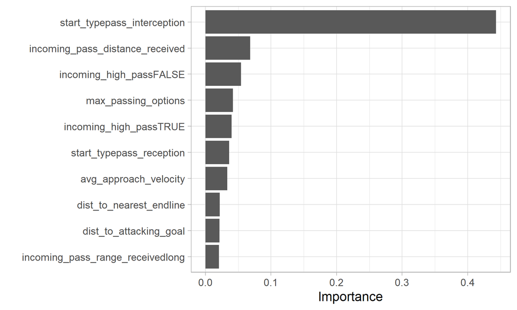

## Results: ROC Curve

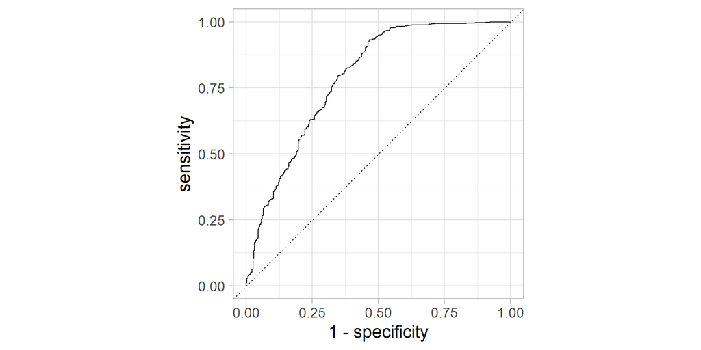

## Limitations

- Inaccuracy in SkillCorner data
- Individual player skill and tactical tendencies not considered in the model
- Our model does not account for pitch control

## Next Steps

1. Use an elliptical (or oval) pressure zone rather than a circular one.

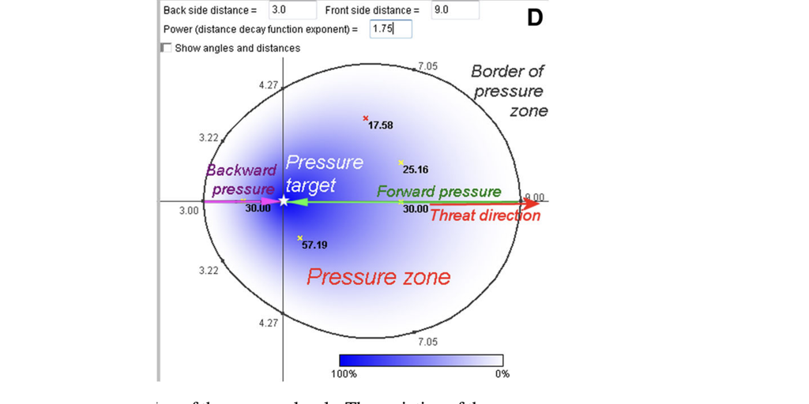

## Next Steps

2. Compare the expected pressure difference from individuals and teams on a scatterplot.

## Next Steps

3. Now that we have an XGBoost model, we plan to compare it with other models, e.g random forest, lightGBM.

[figure not shown]

## Appendix

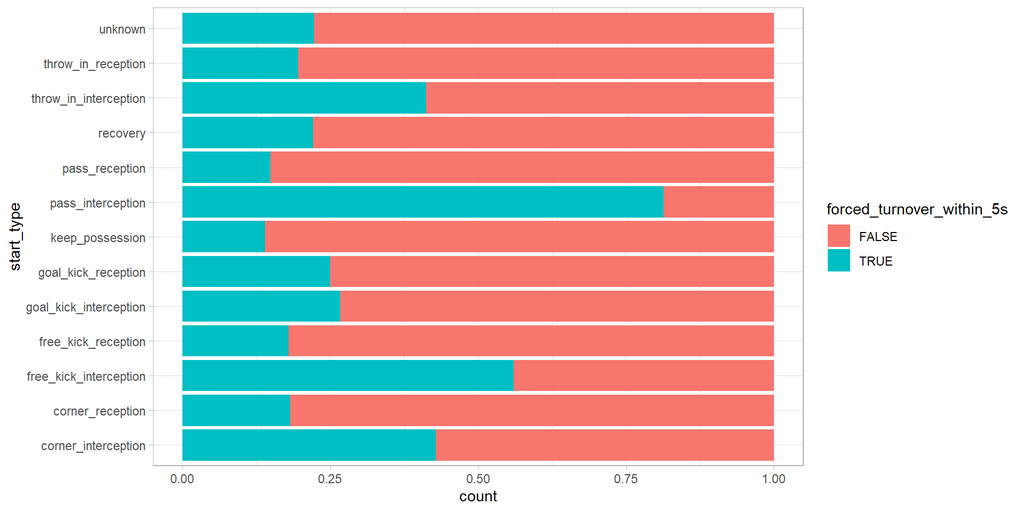